# Tugas Kuliah 2 No. 2

Tri Ananda Marpaung | M0401241098

# 1. Persiapan Data

```r
data <- data.frame(
  Year = 1975:2014,
  Sales = c(
    11.7, 12.2, 12.3, 12.8, 13.1, 13.6, 13.9, 14.4,
    14.7, 15.3, 15.5, 15.8, 16.1, 16.6, 16.9, 16.7,
    16.9, 17.4, 17.6, 17.9, 18.0, 17.9, 18.0, 18.2,
    18.2, 18.3, 18.6, 19.2, 19.3, 19.5, 19.2, 19.3,
    19.5, 20.0, 20.0, 19.9, 19.8, 19.9, 20.2, 21.0
  ),
  Advertising = c(
    9.4, 9.6, 10.0, 10.4, 10.8, 10.9, 11.7, 12.2,
    12.5, 12.9, 13.0, 13.2, 13.8, 14.2, 14.6, 14.4,
    15.0, 15.4, 15.7, 15.9, 15.9, 16.0, 16.3, 16.2,
    16.8, 17.3, 17.6, 18.1, 18.3, 18.5, 18.7, 18.9,
    19.2, 20.0, 20.0, 20.3, 20.4, 21.0, 21.5, 22.1
  )
)

head(data)
```

```
##   Year Sales Advertising
## 1 1975  11.7         9.4
## 2 1976  12.2         9.6
## 3 1977  12.3        10.0
## 4 1978  12.8        10.4
## 5 1979  13.1        10.8
## 6 1980  13.6        10.9
```

# 2. Ekplorasi Data

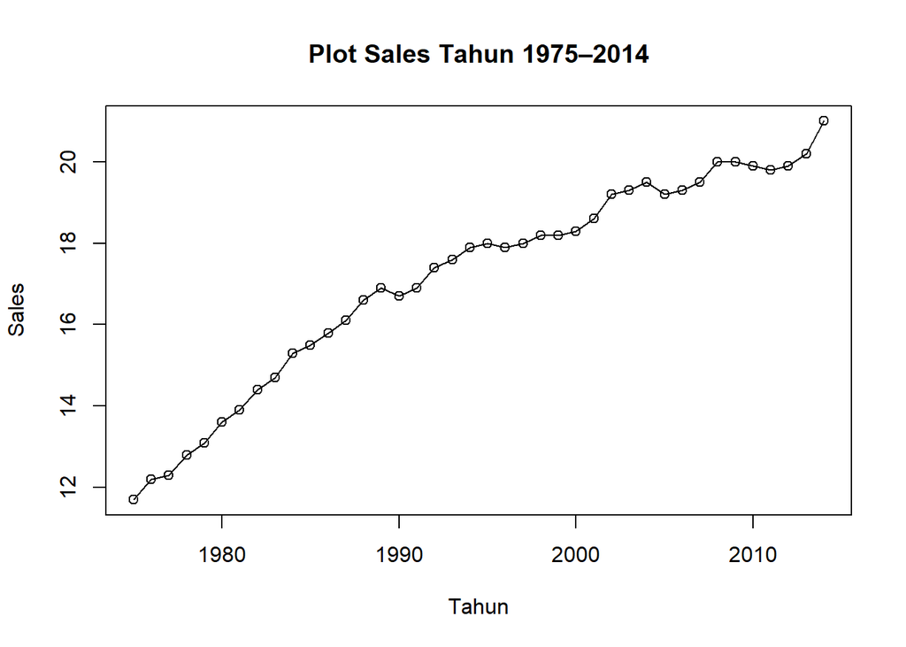

```r
plot(
  data$Year,
  data$Sales,
  type = "o",
  xlab = "Tahun",
  ylab = "Sales",
  main = "Plot Sales Tahun 1975–2014"
)
```

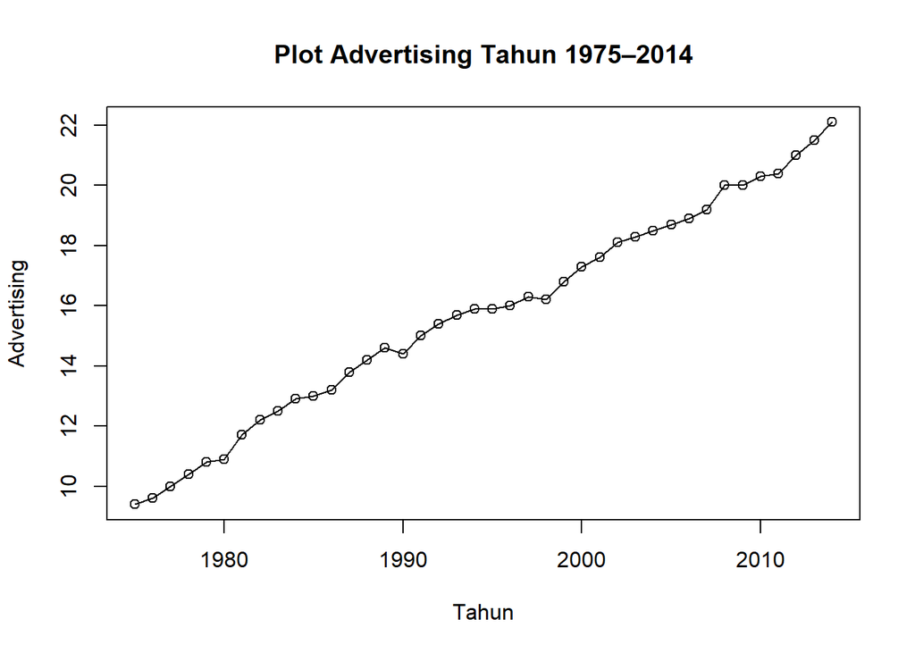

```r
plot(
  data$Year,
  data$Advertising,
  type = "o",
  xlab = "Tahun",
  ylab = "Advertising",
  main = "Plot Advertising Tahun 1975–2014"
)
```

# 3. Membentuk Model Regresi Awal

```r
model_awal <- lm(
  Sales ~ Advertising,
  data = data
)

summary(model_awal)
```

```
##
## Call:
## lm(formula = Sales ~ Advertising, data = data)
##
## Residuals:
##      Min       1Q   Median       3Q      Max
## -1.02833 -0.41303  0.08859  0.44849  0.73581
##
## Coefficients:
##             Estimate Std. Error t value Pr(>|t|)
## (Intercept)  6.00885    0.37587   15.99   <2e-16 ***
## Advertising  0.70788    0.02333   30.34   <2e-16 ***
## ---
## Signif. codes:  0 '***' 0.001 '**' 0.01 '*' 0.05 '.' 0.1 ' ' 1
##
## Residual standard error: 0.52 on 38 degrees of freedom
## Multiple R-squared:  0.9603, Adjusted R-squared:  0.9593
## F-statistic: 920.3 on 1 and 38 DF,  p-value: < 2.2e-16
```

```
                    ŷ = 6.0089 + 0.7079Xt
```

Jadi, secara hubungan linear, Advertising sangat kuat menjelaskan variasi Sales.

# 4. Plot Sisaan

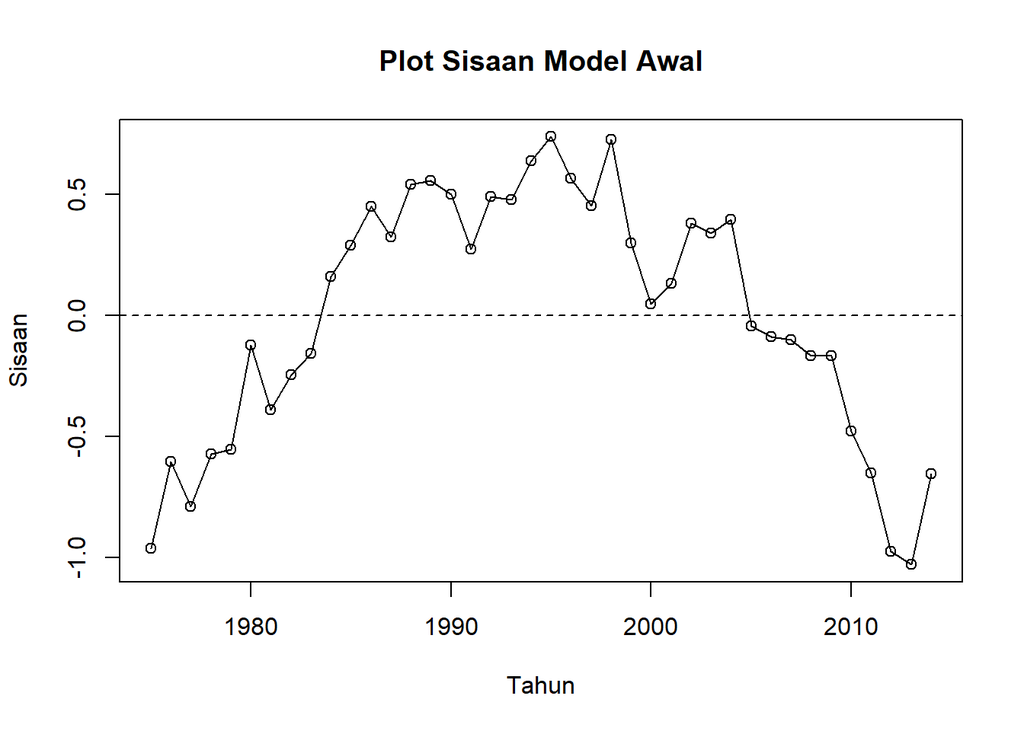

```r
# Mengambil sisaan
res_awal <- residuals(model_awal)

# Plot sisaan terhadap waktu
plot(
  data$Year,
  res_awal,
  type = "o",
  xlab = "Tahun",
  ylab = "Sisaan",
  main = "Plot Sisaan Model Awal"
)

abline(h = 0, lty = 2)
```

Jika sisaan benar-benar bebas, titik sisaan seharusnya menyebar secara acak di sekitar nol. Pada data ini, sisaan menunjukkan pola yang cukup sistematis/ berurutan, bukan penyebaran acak sepenuhnya. Hal tersebut menjadi indikasi awal adalah autokorelasi positif.

# 5. Uji Durbin-Watson

```r
library(lmtest)
library(lmtest)

dwtest(model_awal)
```

```
##
##  Durbin-Watson test
##
## data:  model_awal
## DW = 0.17956, p-value < 2.2e-16
## alternative hypothesis: true autocorrelation is greater than 0
```

Nilai Durbin-Watson –> d = 0.17956 Nilai tersebut sangat dekat dengan 0.

Dengan n = 40 dan k = 1, nilai d = 0,1796 menunjukkan autokorelasi positif yang kuat.

# 6. Penanganan menggunakan Cochrane-Orcutt

```r
# Sisaan model awal
e <- residuals(model_awal)

# Estimasi phi awal
phi_lama <- 0

for(i in 1:100){

  # Menduga phi
  phi_baru <- sum(e[-1] * e[-length(e)]) /
              sum(e[-length(e)]^2)

  # Transformasi Y dan X
  Y_star <- data$Sales[-1] -
            phi_baru * data$Sales[-nrow(data)]

  X_star <- data$Advertising[-1] -
            phi_baru * data$Advertising[-nrow(data)]

  # Regresi data transformasi
  model_star <- lm(
    Y_star ~ X_star
  )

  # Membentuk sisaan baru
  beta0 <- coef(model_star)[1] /
           (1 - phi_baru)

  beta1 <- coef(model_star)[2]

  e_baru <- data$Sales -
            (beta0 + beta1 * data$Advertising)

  # Cek konvergensi
  if(abs(phi_baru - phi_lama) < 0.000001){
    break
  }

  phi_lama <- phi_baru
  e <- e_baru
}

phi_baru
```

```
## [1] 0.8992025
```

```r
beta0
```

```
## (Intercept)
##    10.26422
```

```r
beta1
```

```
##    X_star
## 0.4864346
```

Hasil akhirnya

```
                 ŷ = 10.26422 + 0.4864Xt
```

Jadi, setelah menganangani autokorelasi, koefisien Advertising berubah dari 0.7079 menjadi 0.4864

# 7. Model Hasil Transformasi

```r
model_star <- lm(
  Y_star ~ X_star
)

summary(model_star)
```

```
##
## Call:
## lm(formula = Y_star ~ X_star)
##
## Residuals:
##      Min       1Q   Median       3Q      Max
## -0.37342 -0.14905  0.01826  0.10810  0.45547
##
## Coefficients:
##             Estimate Std. Error t value Pr(>|t|)
## (Intercept)  1.03461    0.14731   7.024 2.64e-08 ***
## X_star       0.48643    0.07606   6.396 1.83e-07 ***
## ---
## Signif. codes:  0 '***' 0.001 '**' 0.01 '*' 0.05 '.' 0.1 ' ' 1
##
## Residual standard error: 0.1936 on 37 degrees of freedom
## Multiple R-squared:  0.5251, Adjusted R-squared:  0.5122
## F-statistic: 40.91 on 1 and 37 DF,  p-value: 1.832e-07
```

```
                 ŷ = 10.26422 + 0.4864Advertising
```

# 8.cek autokorelasi

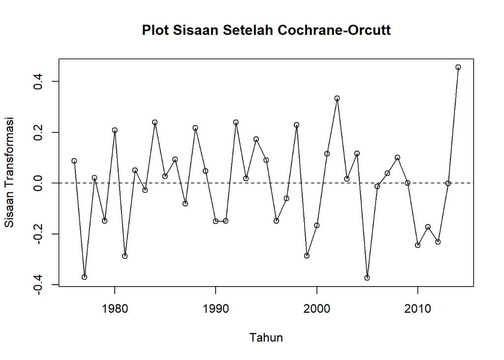

```r
res_co <- residuals(model_star)

plot(
  data$Year[-1],
  res_co,
  type = "o",
  xlab = "Tahun",
  ylab = "Sisaan Transformasi",
  main = "Plot Sisaan Setelah Cochrane-Orcutt"
)

abline(h = 0, lty = 2)
```

```r
dwtest(model_star)
```

```
##
##  Durbin-Watson test
##
## data:  model_star
## DW = 2.0202, p-value = 0.4774
## alternative hypothesis: true autocorrelation is greater than 0
```

Karena nilai DW setelah transformasi mendekati 2, maka tidak terdapat indikasi kuat autokorelasi sisaan. d = 2(1 - r1) Sehingga nilai DW yang mendekati 2 menunjukkan autokorelasi lag-1 yang mendekati nol. Dengan demikian, metode Cochrane-Orcutt berhasil menangani permasalahan autokorelasi pada model regresi deret waktu.